# Using machine learning to predict exercise performance

Tom Defoe

20 December 2015

# Executive Summary

A number of different machine learning algorithms were applied to data from the [Qualitative Activity Recognition of Weight Lifting Exercises](http://groupware.les.inf.puc-rio.br/har) study in order to develop a model that could predict the manner in which participants were likely to perform the exercise.

Of the models evaluated, those using the Random Forest and C5.0 Decision Tree classifiers performed best, with the random forest model achieving a 100% success rate when used to classify the provided test cases.

# Background

It is now possible to collect a large amount of data about personal activity using devices such as those from Fitbit, Jawbone, Samsung and Apple. This data can be analysed to quantify how much of a particular activity people undertake.

This project uses data from accelerometers on the belt, forearm, arm, and dumbell of 6 participants in a test study to evaluate how well each participant is performing the activity. Each participant was asked to perform barbell lifts correctly and incorrectly in 5 different ways. More information about the Weight Lifting Exercise Dataset is available from the following webiste: http://groupware.les.inf.puc-rio.br/har

The goal of the analysis presented in this paper is to build machine learnning algorithms that use this accelerometer data to classify and predict the way in which a participant will perform dumbell activities.

# Data Analysis

## Getting and cleaning the data

The training and test data was provided as two .csv files, both of which contained a large number of missing data points. Since covariates which frequently contain missing data are unlikely to be useful predictors, those columns containing signficant numbers of NAs were removed from the training and testing datasets. Additionally, the decision was taken to remove those columns which are used to identify the participant or specific observation since they should not form part of a machine learning algorithm.

```r
# Load the training and test case datasets
rawTrainData <- read.table("pml-training.csv", sep = ",", header = TRUE,
                           na.strings=c("NA","", "#DIV/0!"))
rawTestCases <- read.table("pml-testing.csv", sep = ",", header = TRUE,
                           na.strings=c("NA","", "#DIV/0!"))

# Clean the datasets by removing columns which contain significant numbers of NAs
total_obs <- nrow(rawTrainData)
count_na <- apply(rawTrainData, 2, function(x) sum(is.na(x)))
trainData <- rawTrainData[, which(count_na / total_obs < 0.25)]
testCases <- rawTestCases[, which(count_na / total_obs < 0.25)]

# Remove those columns which are used to identify rather than describe the observation
dropColumns <- c('X', 'user_name', 'raw_timestamp_part_1', 'raw_timestamp_part_2',
                 'cvtd_timestamp', 'new_window', 'num_window')
trainData <- subset(trainData, select = !(names(trainData) %in% dropColumns))
testCases <- subset(testCases, select = !(names(testCases) %in% dropColumns))
```

## Pre-processing the data

The resulting datasets still contain 53 different covariates; if possible we would like to develop machine learning algorithms that can be run against simpler datasets that still capture all of the key information. As a first step, the training set was checked for covariates that have little variability. However, as it turned out, none of the covariates had near zero variablility and so all were retained at this stage.

```r
# Check for covariates with near zero variability
nsv <- nearZeroVar(trainData, saveMetrics=TRUE)
sum(nsv$nzv)
```

[output not shown]

The second step looked at the correlation between variables in the training set. The following grid shows the correlation between each pair of the predictors in the training dataset; darker shaded squares indicate high positive and negative correlations.

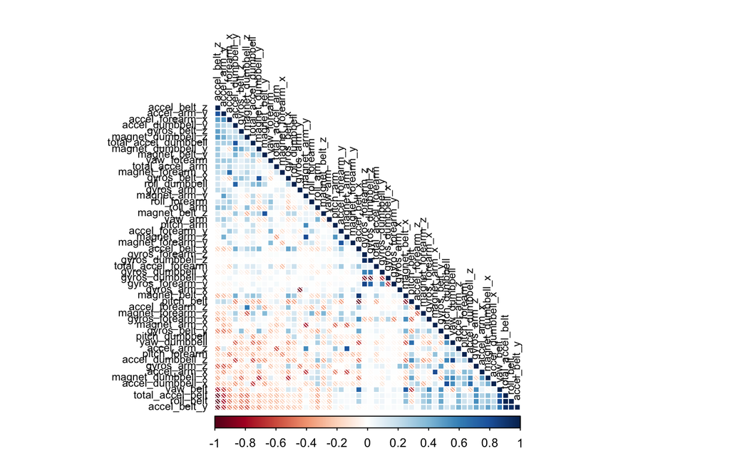

```r
# Plot correlation between variables in the training data
# Ignore the last column as this contains the classe variable we are predicting
corrMatrix <- cor(trainData[, -ncol(trainData)])
corrplot(corrMatrix, method = 'shade', order = 'FPC', type = 'lower',tl.cex = 0.7, tl.col = 'black')
```

While there is generally low correlation between the predictors, a small number of variables are highly correlated. Although principal component analysis (PCA) could be used to produce a smaller set of uncorrelated variables, the decision was taken to preserve interpretability of the model by identifying and then removing the highly correlated variables. This analysis resulted in removal of accel_belt_z, roll_belt, accel_belt_y, accel_belt_x, gyros_dumbbell_x, gyros_dumbbell_z, and gyroz_arm_z from the subsequent analysis.

```r
# Remove highly correlated variables from training dataset and test cases
hc_index <- findCorrelation(corrMatrix, cutoff = 0.90, names = FALSE)
trainData <- trainData[, -hc_index]
testCases <- testCases[, -hc_index]
```

Finally, while most of the coveriates are relatively well distributed, a number of them showed relatively high levels of skew. Therefore, the data was pre-processed to make sure it was properly centred and scaled.

```r
# Center and scale data in the training dataset and test cases
preProcObj <- preProcess(trainData, method = c("center", "scale"))
trainData <- predict(preProcObj, trainData)
testCases <- predict(preProcObj, testCases)
```

## Creating the cross-validation datasets

The training dataset was then partitioned into training, test and validation sets. The training dataset comprised around 50% of the observations, while the testing dataset contained round 20% of the observations, and the remaining 30% of observations comprised the validation dataset. At this point, each partition of the data contained 46 covariates that were to be used during model development.

# Model Development

Four different models were developed using data from the training partition and then cross-validated using data from the testing partition. The models developed were:

- Recursive Partitioning and Regression Trees (from the rpart pacakge)
- C5.0 Decision Tree Classifier (from the C50 package)
- Random Forest (from the randomforest package)
- Support Vector Machine (from the e1071 package)

Of these, the C5.0 classifier and Random Forest classifier were found to perform very well when evaluated against the data from the testing partition.

## Model 1: Recursive Partition and Regression Trees

The first model implemented a simple tree classifier, using the rpart algorithm with the default tuning parameters provided by the caret package. While creation of the model is fast, the results are not impressive. The model has an estimated accuracy of 54.5% on the partitioned training data and an estimated cross-validation accuracy of 53.8% when evaluated using the partitioned testing data.

```
##       Accuracy          Kappa  AccuracyLower  AccuracyUpper   AccuracyNull
##     5.3813e-01     4.2150e-01     5.2275e-01     5.5344e-01     2.8436e-01
## AccuracyPValue  McnemarPValue
##    1.3149e-254    1.3323e-279
```

## Model 2: C5.0 Decision Tree Classifier

The second model implements a C5.0 decision tree classifier with 10 boosting iterations, using the c50 package. This statistical classifier uses information entropy concepts to produce what are generally considered to be highly accurate and reliable classification models. Although 10 boosting iterations were requested, the model actually converged after just a single run. The model has an estimated accuracy of 100% on the partitioned training data and an estimated cross-validation accuracy of 98.7% when evaluated using the partitioned testing data.

```
##       Accuracy          Kappa  AccuracyLower  AccuracyUpper   AccuracyNull
##        0.98713        0.98372        0.98320        0.99034        0.28436
## AccuracyPValue  McnemarPValue
##        0.00000            NaN
```

## Model 3: Random Forest Classifier

The random forest classifier provider by the randomforest package uses a bootstrapping technique to create many different trees which each use different samples of the data at every split point (using the tuning parameters adopted in this study, 500 trees were created with 6 different variables tried at each split). A majority voting approach is then used to aggregate the different trees and create a final result. In general random forests have a high degree of predictive power but are computationally expensive, can be prone to overfitting and lack interpretability. As anticipated, this model achieved 100% accuracy on the training partition and an excellent 99.2% accuracy on the testing partition.

```
##       Accuracy          Kappa  AccuracyLower  AccuracyUpper   AccuracyNull
##        0.99223        0.99017        0.98905        0.99468        0.28436
## AccuracyPValue  McnemarPValue
##        0.00000            NaN
```

## Model 4: Support Vector Machine

```
##       Accuracy          Kappa  AccuracyLower  AccuracyUpper   AccuracyNull
##     9.2496e-01     9.0491e-01     9.1649e-01     9.3283e-01     2.8436e-01
## AccuracyPValue  McnemarPValue
##     0.0000e+00     2.2610e-34
```

# Test Case Predictions

From the results in the previous section, it can be seen that the C5.0 decision tree classifier and random forest algorithm both achieved very good levels of accuracy when run against the test partition. While a stacked model that combined both algorithms could be developed in an attempt to improve accuracy still further, this is probably not necessary in this case. Instead the random forest algorithm (Model 3) was selected as the final model and run against the 20 unlabelled test cases provided. This resulted in the following classifications:

```r
predictCases3 <- predict(model3, testCases)
predictCases3
```

```
##  1  2  3  4  5  6  7  8  9 10 11 12 13 14 15 16 17 18 19 20
##  B  A  B  A  A  E  D  B  A  A  B  C  B  A  E  E  A  B  B  B
## Levels: A B C D E
```

# Conclusions

The results for the random forest model were very good - its evaluated accuracy when run against the partitioned testing data provides an estimated out-of-sample error rate of 0.8%. The results for the C5.0 decision tree classifier were also good with an estimated out-of-sample error rate of 1.3%. The random forest model was used to correctly classify all 20 sample test cases, demonstrating its predictive power on this small sample of test cases.

# Appendix 1 - Supporting code

```r
# MODEL 1: Classification tree using default tuning parameters
buildStart <- Sys.time()
model1 <- train(classe ~ ., data = training, method="rpart")
buildEnd <- Sys.time()
buildTime1 <- buildEnd - buildStart
paste("Training time:", buildTime1, "seconds")

trainPredict1 <- predict(model1, training)
testPredict1 <- predict(model1, testing)

confusionMatrix(trainPredict1, training$classe)$overall
confusionMatrix(testPredict1, testing$classe)$overall
confusionMatrix(testPredict1, testing$classe)$table
# Model has estimated accuracy of 54.5% on training set and 53.8% on testing set

predictCases1 <- predict(model1, testCases)
predictCases1
# C C C C C C C C A A D C C A C B C D C B
```

```r
# MODEL 2: C5.0 Decision Tree Classifier with 10 boosting iterations
buildStart <- Sys.time()
model2 <- C5.0(classe ~ ., data = training, trials = 10)
buildEnd <- Sys.time()
buildTime2 <- buildEnd - buildStart
paste("Training time:", buildTime2, "seconds")

trainPredict2 <- predict(model2, training)
testPredict2 <- predict(model2, testing)

confusionMatrix(trainPredict2, training$classe)$overall
confusionMatrix(testPredict2, testing$classe)$overall
confusionMatrix(testPredict2, testing$classe)$table
# Model has estimated accuracy of 100% on training set and 98.8% on testing set

predictCases2 <- predict(model2, testCases)
predictCases2
# B A B A A E D D A A B C B A E E A B B B
```

```r
# MODEL 3: Random forest using the randomforest package
buildStart <- Sys.time()
model3 <- randomForest(classe ~ ., data = training, importance = TRUE)
buildEnd <- Sys.time()
buildTime3 <- buildEnd - buildStart
paste("Training time:", buildTime3, "seconds")

trainPredict3 <- predict(model3, training)
testPredict3 <- predict(model3, testing)

confusionMatrix(trainPredict3, training$classe)$overall
confusionMatrix(testPredict3, testing$classe)$overall
confusionMatrix(testPredict3, testing$classe)$table
# Model has estimated accuracy of 100% on training set and 99.2% on testing set

# varImp(model3)

predictCases3 <- predict(model3, testCases)
predictCases3
# B A B A A E D B A A B C B A E E A B B B
```

```r
# MODEL 4: Support Vector Machine using the e1071 package
buildStart <- Sys.time()
model4 <- svm(classe ~ ., data = training)
buildEnd <- Sys.time()
buildTime4 <- buildEnd - buildStart
paste("Training time:", buildTime4, "seconds")

trainPredict4 <- predict(model4, training)
testPredict4 <- predict(model4, testing)

confusionMatrix(trainPredict4, training$classe)$overall
confusionMatrix(testPredict4, testing$classe)$overall
confusionMatrix(testPredict4, testing$classe)$table
# Model has estimated accuracy of 93.9% on the training set and 92.5% on the validation set

predictCases4 <- predict(model4, testCases)
predictCases4
# A A A A A E D B A A B C B A E E A B B B
```